# MovieLens Project_Seenivasan_Kittappa

### Project - MovieLens Data Analysis

The GroupLens Research Project is a research group in the Department of Computer Science and Engineering at the University of Minnesota. The data is widely used for collaborative filtering and other filtering solutions. However, we will be using this data to act as a means to demonstrate our skill in using Python to “play” with data.

#### Domain

Internet and Entertainment

**Note that the project will need you to apply the concepts of groupby and merging extensively.**

```python
import numpy as np
import pandas as pd
import seaborn as sns
from matplotlib import pyplot as plt
```

#### 1. Import the necessary packages - 2.5 marks

```python
movie_ratings = pd.read_csv('data.csv')
movie_ratings.head()
```

|  | user id | movie id | rating | timestamp |
| --- | --- | --- | --- | --- |
| 0 | 196 | 242 | 3 | 881250949 |
| 1 | 186 | 302 | 3 | 891717742 |
| 2 | 22 | 377 | 1 | 878887116 |
| 3 | 244 | 51 | 2 | 880606923 |
| 4 | 166 | 346 | 1 | 886397596 |

```python
print(movie_ratings.shape)
print(movie_ratings.size)
```

```
(100000, 4)
400000
```

```python
movie_genre = pd.read_csv('item.csv')
movie_genre.head()
```

|  | movie id | movie title | release date | unknown | Action | Adventure | Animation | Childrens | Comedy | Crime | ... | Fantasy | Film-Noir | Horror | Musical | Mystery | Romance | Sci-Fi | Thriller | War | Western |
| --- | --- | --- | --- | --- | --- | --- | --- | --- | --- | --- | --- | --- | --- | --- | --- | --- | --- | --- | --- | --- | --- |
| 0 | 1 | Toy Story | 01-Jan-1995 | 0 | 0 | 0 | 1 | 1 | 1 | 0 | ... | 0 | 0 | 0 | 0 | 0 | 0 | 0 | 0 | 0 | 0 |
| 1 | 2 | GoldenEye | 01-Jan-1995 | 0 | 1 | 1 | 0 | 0 | 0 | 0 | ... | 0 | 0 | 0 | 0 | 0 | 0 | 0 | 1 | 0 | 0 |
| 2 | 3 | Four Rooms | 01-Jan-1995 | 0 | 0 | 0 | 0 | 0 | 0 | 0 | ... | 0 | 0 | 0 | 0 | 0 | 0 | 0 | 1 | 0 | 0 |
| 3 | 4 | Get Shorty | 01-Jan-1995 | 0 | 1 | 0 | 0 | 0 | 1 | 0 | ... | 0 | 0 | 0 | 0 | 0 | 0 | 0 | 0 | 0 | 0 |
| 4 | 5 | Copycat | 01-Jan-1995 | 0 | 0 | 0 | 0 | 0 | 0 | 1 | ... | 0 | 0 | 0 | 0 | 0 | 0 | 0 | 1 | 0 | 0 |

5 rows × 22 columns

```python
print(movie_genre.shape)
print(movie_genre.size)
```

```
(1681, 22)
36982
```

```python
customer_profile = pd.read_csv('user.csv')
customer_profile.head()
```

|  | user id | age | gender | occupation | zip code |
| --- | --- | --- | --- | --- | --- |
| 0 | 1 | 24 | M | technician | 85711 |
| 1 | 2 | 53 | F | other | 94043 |
| 2 | 3 | 23 | M | writer | 32067 |
| 3 | 4 | 24 | M | technician | 43537 |
| 4 | 5 | 33 | F | other | 15213 |

```python
print(customer_profile.shape)
print(customer_profile.size)
```

```
(943, 5)
4715
```

```python
df=pd.merge(movie_ratings,movie_genre,how='left',on='movie id')
df.head()
```

|  | user id | movie id | rating | timestamp | movie title | release date | unknown | Action | Adventure | Animation | ... | Fantasy | Film-Noir | Horror | Musical | Mystery | Romance | Sci-Fi | Thriller | War | Western |
| --- | --- | --- | --- | --- | --- | --- | --- | --- | --- | --- | --- | --- | --- | --- | --- | --- | --- | --- | --- | --- | --- |
| 0 | 196 | 242 | 3 | 881250949 | Kolya | 24-Jan-1997 | 0.0 | 0.0 | 0.0 | 0.0 | ... | 0.0 | 0.0 | 0.0 | 0.0 | 0.0 | 0.0 | 0.0 | 0.0 | 0.0 | 0.0 |
| 1 | 186 | 302 | 3 | 891717742 | L.A. Confidential | 01-Jan-1997 | 0.0 | 0.0 | 0.0 | 0.0 | ... | 0.0 | 1.0 | 0.0 | 0.0 | 1.0 | 0.0 | 0.0 | 1.0 | 0.0 | 0.0 |
| 2 | 22 | 377 | 1 | 878887116 | Heavyweights | 01-Jan-1994 | 0.0 | 0.0 | 0.0 | 0.0 | ... | 0.0 | 0.0 | 0.0 | 0.0 | 0.0 | 0.0 | 0.0 | 0.0 | 0.0 | 0.0 |
| 3 | 244 | 51 | 2 | 880606923 | Legends of the Fall | 01-Jan-1994 | 0.0 | 0.0 | 0.0 | 0.0 | ... | 0.0 | 0.0 | 0.0 | 0.0 | 0.0 | 1.0 | 0.0 | 0.0 | 1.0 | 1.0 |
| 4 | 166 | 346 | 1 | 886397596 | Jackie Brown | 01-Jan-1997 | 0.0 | 0.0 | 0.0 | 0.0 | ... | 0.0 | 0.0 | 0.0 | 0.0 | 0.0 | 0.0 | 0.0 | 0.0 | 0.0 | 0.0 |

5 rows × 25 columns

```python
movie_df=pd.merge(df,customer_profile,how='left',on='user id')
movie_df.head()
```

|  | user id | movie id | rating | timestamp | movie title | release date | unknown | Action | Adventure | Animation | ... | Mystery | Romance | Sci-Fi | Thriller | War | Western | age | gender | occupation | zip code |
| --- | --- | --- | --- | --- | --- | --- | --- | --- | --- | --- | --- | --- | --- | --- | --- | --- | --- | --- | --- | --- | --- |
| 0 | 196 | 242 | 3 | 881250949 | Kolya | 24-Jan-1997 | 0.0 | 0.0 | 0.0 | 0.0 | ... | 0.0 | 0.0 | 0.0 | 0.0 | 0.0 | 0.0 | 49 | M | writer | 55105 |
| 1 | 186 | 302 | 3 | 891717742 | L.A. Confidential | 01-Jan-1997 | 0.0 | 0.0 | 0.0 | 0.0 | ... | 1.0 | 0.0 | 0.0 | 1.0 | 0.0 | 0.0 | 39 | F | executive | 00000 |
| 2 | 22 | 377 | 1 | 878887116 | Heavyweights | 01-Jan-1994 | 0.0 | 0.0 | 0.0 | 0.0 | ... | 0.0 | 0.0 | 0.0 | 0.0 | 0.0 | 0.0 | 25 | M | writer | 40206 |
| 3 | 244 | 51 | 2 | 880606923 | Legends of the Fall | 01-Jan-1994 | 0.0 | 0.0 | 0.0 | 0.0 | ... | 0.0 | 1.0 | 0.0 | 0.0 | 1.0 | 1.0 | 28 | M | technician | 80525 |
| 4 | 166 | 346 | 1 | 886397596 | Jackie Brown | 01-Jan-1997 | 0.0 | 0.0 | 0.0 | 0.0 | ... | 0.0 | 0.0 | 0.0 | 0.0 | 0.0 | 0.0 | 47 | M | educator | 55113 |

5 rows × 29 columns

```python
movie_df=pd.merge(df,customer_profile,how='left',on='user id')
movie_df.head()
```

|  | user id | movie id | rating | timestamp | movie title | release date | unknown | Action | Adventure | Animation | ... | Mystery | Romance | Sci-Fi | Thriller | War | Western | age | gender | occupation | zip code |
| --- | --- | --- | --- | --- | --- | --- | --- | --- | --- | --- | --- | --- | --- | --- | --- | --- | --- | --- | --- | --- | --- |
| 0 | 196 | 242 | 3 | 881250949 | Kolya | 24-Jan-1997 | 0.0 | 0.0 | 0.0 | 0.0 | ... | 0.0 | 0.0 | 0.0 | 0.0 | 0.0 | 0.0 | 49 | M | writer | 55105 |
| 1 | 186 | 302 | 3 | 891717742 | L.A. Confidential | 01-Jan-1997 | 0.0 | 0.0 | 0.0 | 0.0 | ... | 1.0 | 0.0 | 0.0 | 1.0 | 0.0 | 0.0 | 39 | F | executive | 00000 |
| 2 | 22 | 377 | 1 | 878887116 | Heavyweights | 01-Jan-1994 | 0.0 | 0.0 | 0.0 | 0.0 | ... | 0.0 | 0.0 | 0.0 | 0.0 | 0.0 | 0.0 | 25 | M | writer | 40206 |
| 3 | 244 | 51 | 2 | 880606923 | Legends of the Fall | 01-Jan-1994 | 0.0 | 0.0 | 0.0 | 0.0 | ... | 0.0 | 1.0 | 0.0 | 0.0 | 1.0 | 1.0 | 28 | M | technician | 80525 |
| 4 | 166 | 346 | 1 | 886397596 | Jackie Brown | 01-Jan-1997 | 0.0 | 0.0 | 0.0 | 0.0 | ... | 0.0 | 0.0 | 0.0 | 0.0 | 0.0 | 0.0 | 47 | M | educator | 55113 |

5 rows × 29 columns

```python
print(movie_df.shape)
```

```
(100000, 29)
```

```python
movie_df.describe
```

[output not shown]

[output cut: 38 more lines]

#### 2. Read the 3 datasets into dataframes - 2.5 marks

```python
print(movie_df.shape)
```

```
(100000, 29)
```

```python
#movie_ratings.shape #Apply shape

movie_df.describe #Apply describe
```

[output not shown]

[output cut: 38 more lines]

```python
movie_df.info
```

[output not shown]

[output cut: 38 more lines]

```python
movie_df.to_csv(r'movies.csv', index = False)

#movie_df.info() #Apply Info
#movie_df.shape #Apply shape
#movie_df.describe() #Apply describe
```

```python
def missing_check(source_df):
    total = source_df.isnull().sum().sort_values(ascending=False)   # total number of null values
    percent = (source_df.isnull().sum()/source_df.isnull().count()).sort_values(ascending=False)  # percentage of values that are null
    missing_data = pd.concat([total, percent], axis=1, keys=['Total', 'Percent'])  # putting the above two together
    return missing_data # return the dataframe
missing_check(movie_df)
```

|  | Total | Percent |
| --- | --- | --- |
| Drama | 9 | 0.00009 |
| movie title | 9 | 0.00009 |
| unknown | 9 | 0.00009 |
| Action | 9 | 0.00009 |
| Adventure | 9 | 0.00009 |
| Animation | 9 | 0.00009 |
| Childrens | 9 | 0.00009 |
| Comedy | 9 | 0.00009 |
| Crime | 9 | 0.00009 |
| Documentary | 9 | 0.00009 |
| Fantasy | 9 | 0.00009 |
| Film-Noir | 9 | 0.00009 |
| Horror | 9 | 0.00009 |
| Musical | 9 | 0.00009 |
| Mystery | 9 | 0.00009 |
| Romance | 9 | 0.00009 |
| Sci-Fi | 9 | 0.00009 |
| Thriller | 9 | 0.00009 |
| War | 9 | 0.00009 |
| Western | 9 | 0.00009 |
| release date | 9 | 0.00009 |
| timestamp | 0 | 0.00000 |
| rating | 0 | 0.00000 |
| movie id | 0 | 0.00000 |
| zip code | 0 | 0.00000 |
| occupation | 0 | 0.00000 |
| age | 0 | 0.00000 |
| gender | 0 | 0.00000 |
| user id | 0 | 0.00000 |

#### 3. Apply info, shape, describe, and find the number of missing values in the data - 5 marks

```python
#movie_genre.head
genre_df=movie_genre.drop(['movie id','release date','movie title'],axis=1)
genre_df.sum()
```

```
unknown          1
Action         251
Adventure      135
Animation       42
Childrens      122
Comedy         505
Crime          109
Documentary     50
Drama          725
Fantasy         22
Film-Noir       24
Horror          92
Musical         56
Mystery         61
Romance        247
Sci-Fi         101
Thriller       251
War             71
Western         27
dtype: int64
```

```python
#cus_profile.info() #Apply Info
movie_genre.shape

#movie_genre.info() #Apply Info
#movie_genre.shape #Apply shape
#movie_genre.describe() #Apply describe
```

```
(1681, 22)
```

```python
# No of missing values
# movie_ratings.isnull().any().any() # - It looks no missing values in movie_ratings

#len(movie_ratings) -movie_ratings.count()
#len(movie_genre) -movie_genre.count()
#len(cus_profile) -cus_profile.count()
```

```python
#df=pd.merge(movie_ratings,movie_genre,how='left',on='movie_id')
#df.head()
```

#### 4. Find the number of movies per genre using the item data - 5 marks

```python
# use sum on the default axis

genre_df.head
(genre_df[genre_df.columns[0:]].sum(axis=1)>1).sum()
```

```
849
```

#### 5. Find the movies that have more than one genre - 2.5 marks

```python
#hint: use sum on the axis = 1
genre_df_ukn=genre_df.drop(genre_df[genre_df['unknown']==1].index,axis=0)
genre_df_ukn['unknown'].sum()
```

```
0
```

#### 6. Drop the movie where the genre is unknown - 2.5 marks

```python
movie_df.head()
data_rating=movie_df['rating']
data_rating.isnull().sum()
```

```
0
```

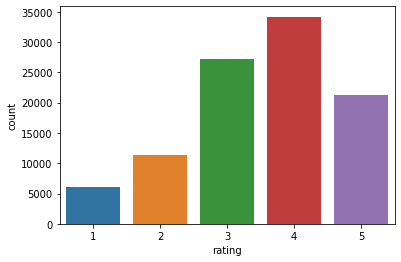

```python
sns.countplot(data_rating)
```

```python
movie_df.head()
data_age=movie_df['age']
data_age.isnull().sum()
```

```
0
```

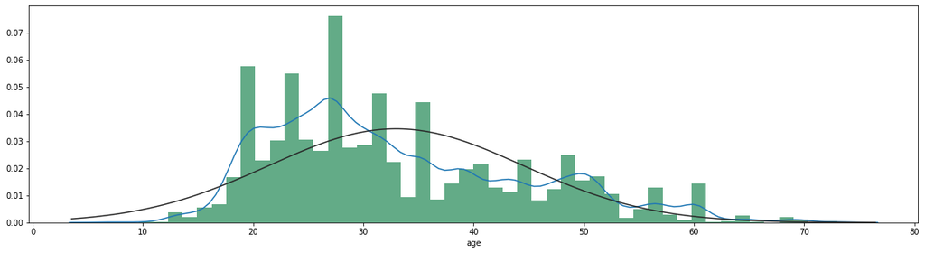

```python
#Univariate plots of columns 'age'
plt.figure(figsize=(20,5))
sns.distplot(data_age)
from scipy.stats import norm
sns.distplot(data_age, fit=norm, kde=False, color="g")
```

```python
movie_df.head()
data_gen=movie_df['gender']
data_gen.isnull().sum()
```

```
0
```

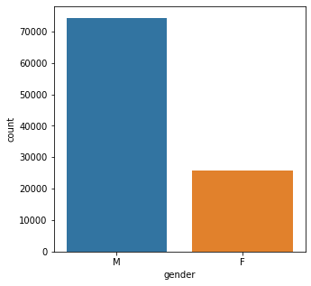

```python
#Univariate plots of columns 'Gender'
plt.figure(figsize=(5,5))
sns.countplot(data_gen)
```

```python
movie_df.head()
data_o=movie_df['occupation']
data_o.isnull().sum()
```

```
0
```

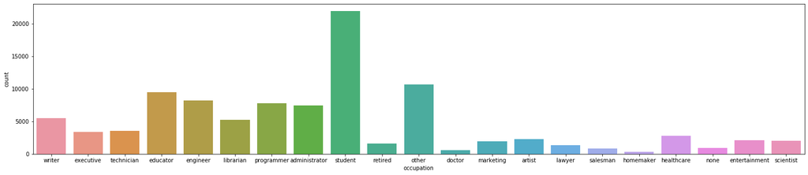

```python
#Univariate plots of columns 'Occupation'
plt.figure(figsize=(25,5))
sns.countplot(data_o)
```

```python
movie_df.head()
data_rating=movie_df['release date']
data_rating.isnull().sum()
data_rating=data_rating.dropna()
data_rating.isnull().sum()
```

```
0
```

```python
data_rating=movie_df['release date'].str[-4:]
data_rating.head()
```

```
0    1997
1    1997
2    1994
3    1994
4    1997
Name: release date, dtype: object
```

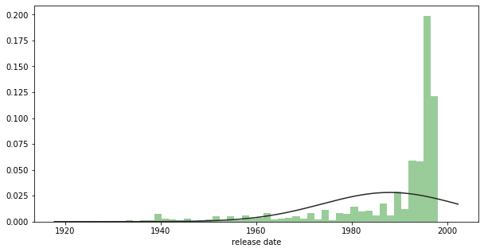

```python
#Univariate plots of columns 'release year'
plt.figure(figsize=(10,5))
sns.distplot(data_rating, fit=norm, kde=False, color="g")
```

### 7. Univariate plots of columns: 'rating', 'Age', 'release year', 'Gender' and 'Occupation' - 10 marks

```python
# HINT: use distplot for age and countplot for gender,ratings,occupation.
# HINT: Please refer to the below snippet to understand how to get to release year from release date. You can use str.split()
# as depicted below
# Hint : Use displot without kde for release year or line plot showing year wise count.
```

```python
a = 'My*cat*is*brown'
print(a.split('*')[3])

#similarly, the release year needs to be taken out from release date

#also you can simply slice existing string to get the desired data, if we want to take out the colour of the cat

print(a[10:])
print(a[-5:])
```

[output not shown]

```python
#your answers here

popular_df=movie_genre.drop(['movie id','movie title'],axis=1)
popular_df.head()
```

|  | release date | unknown | Action | Adventure | Animation | Childrens | Comedy | Crime | Documentary | Drama | Fantasy | Film-Noir | Horror | Musical | Mystery | Romance | Sci-Fi | Thriller | War | Western |
| --- | --- | --- | --- | --- | --- | --- | --- | --- | --- | --- | --- | --- | --- | --- | --- | --- | --- | --- | --- | --- |
| 0 | 01-Jan-1995 | 0 | 0 | 0 | 1 | 1 | 1 | 0 | 0 | 0 | 0 | 0 | 0 | 0 | 0 | 0 | 0 | 0 | 0 | 0 |
| 1 | 01-Jan-1995 | 0 | 1 | 1 | 0 | 0 | 0 | 0 | 0 | 0 | 0 | 0 | 0 | 0 | 0 | 0 | 0 | 1 | 0 | 0 |
| 2 | 01-Jan-1995 | 0 | 0 | 0 | 0 | 0 | 0 | 0 | 0 | 0 | 0 | 0 | 0 | 0 | 0 | 0 | 0 | 1 | 0 | 0 |
| 3 | 01-Jan-1995 | 0 | 1 | 0 | 0 | 0 | 1 | 0 | 0 | 1 | 0 | 0 | 0 | 0 | 0 | 0 | 0 | 0 | 0 | 0 |
| 4 | 01-Jan-1995 | 0 | 0 | 0 | 0 | 0 | 0 | 1 | 0 | 1 | 0 | 0 | 0 | 0 | 0 | 0 | 0 | 1 | 0 | 0 |

```python
popular_df = popular_df.apply(lambda x: x.str[-4:] if x.name == 'release date' else x)
popular_df.head()
```

|  | release date | unknown | Action | Adventure | Animation | Childrens | Comedy | Crime | Documentary | Drama | Fantasy | Film-Noir | Horror | Musical | Mystery | Romance | Sci-Fi | Thriller | War | Western |
| --- | --- | --- | --- | --- | --- | --- | --- | --- | --- | --- | --- | --- | --- | --- | --- | --- | --- | --- | --- | --- |
| 0 | 1995 | 0 | 0 | 0 | 1 | 1 | 1 | 0 | 0 | 0 | 0 | 0 | 0 | 0 | 0 | 0 | 0 | 0 | 0 | 0 |
| 1 | 1995 | 0 | 1 | 1 | 0 | 0 | 0 | 0 | 0 | 0 | 0 | 0 | 0 | 0 | 0 | 0 | 0 | 1 | 0 | 0 |
| 2 | 1995 | 0 | 0 | 0 | 0 | 0 | 0 | 0 | 0 | 0 | 0 | 0 | 0 | 0 | 0 | 0 | 0 | 1 | 0 | 0 |
| 3 | 1995 | 0 | 1 | 0 | 0 | 0 | 1 | 0 | 0 | 1 | 0 | 0 | 0 | 0 | 0 | 0 | 0 | 0 | 0 | 0 |
| 4 | 1995 | 0 | 0 | 0 | 0 | 0 | 0 | 1 | 0 | 1 | 0 | 0 | 0 | 0 | 0 | 0 | 0 | 1 | 0 | 0 |

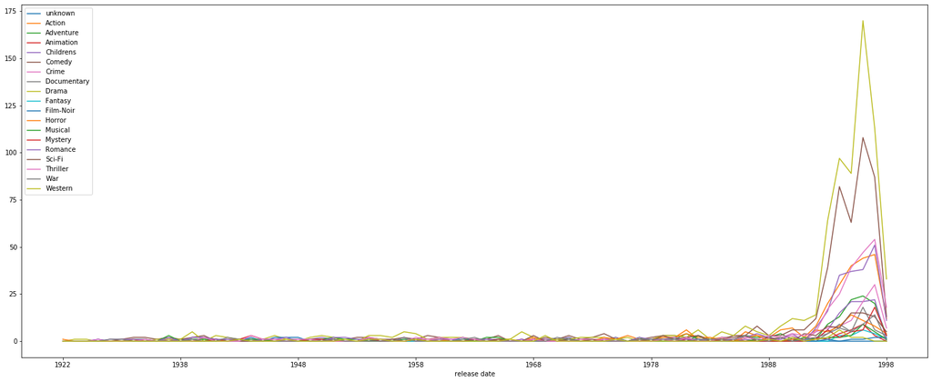

```python
#Visualize how popularity of genres has changed over the years - 10 marks
populargrp_df=popular_df.groupby('release date').sum()
populargrp_df.head
plt.figure(figsize=(20,5))
populargrp_df.plot(kind='line',figsize=(25,10))
#sns.heatmap(populargrp_df, annot=True)
```

### 8. Visualize how popularity of genres has changed over the years - 10 marks

Note that you need to use the number of releases in a year as a parameter of popularity of a genre

Hint

1: you need to reach to a data frame where the release year is the index and the genre is the column names (one cell shows the number of release in a year in one genre) or vice versa. Once that is achieved, you can either use univariate plots or can use the heatmap to visualise all the changes over the years in one go.

Hint 2: Use groupby on the relevant column and use sum() on the same to find out the nuumber of releases in a year/genre.

```python
#Your answer here

movie_df.head()
movie_df.dropna()
movie_df.head()

movie_df_grp = movie_df.groupby(by=['movie title'])['rating'].count().reset_index().sort_values(['rating'],
                    ascending=False)

movie_df_grp = movie_df_grp.where(movie_df_grp['rating']>100)
movie_df_grp.mean()
movie_df_grp = movie_df.groupby(by=['movie title'])['rating'].mean().reset_index().sort_values(['rating'],
                    ascending=False).head(25)
movie_df_grp.head(25)
```

|  | movie title | rating |
| --- | --- | --- |
| 632 | Great Day in Harlem, A | 5.000000 |
| 1171 | Prefontaine | 5.000000 |
| 1355 | Someone Else's America | 5.000000 |
| 943 | Marlene Dietrich: Shadow and Light ( | 5.000000 |
| 461 | Entertaining Angels: The Dorothy Day Story | 5.000000 |
| 1383 | Star Kid | 5.000000 |
| 1467 | They Made Me a Criminal | 5.000000 |
| 30 | Aiqing wansui | 5.000000 |
| 1271 | Saint of Fort Washington, The | 5.000000 |
| 1275 | Santa with Muscles | 5.000000 |
| 1129 | Pather Panchali | 4.625000 |
| 1353 | Some Mother's Son | 4.500000 |
| 79 | Anna | 4.500000 |
| 955 | Maya Lin: A Strong Clear Vision | 4.500000 |
| 471 | Everest | 4.500000 |
| 317 | Close Shave, A | 4.491071 |
| 1278 | Schindler's List | 4.466443 |
| 1647 | Wrong Trousers, The | 4.466102 |
| 272 | Casablanca | 4.456790 |
| 1592 | Wallace & Gromit: The Best of Aardman Animation | 4.447761 |
| 1313 | Shawshank Redemption, The | 4.445230 |
| 1214 | Rear Window | 4.387560 |
| 1567 | Usual Suspects, The | 4.385768 |
| 1394 | Star Wars | 4.358491 |
| 3 | 12 Angry Men | 4.344000 |

Hint :

1. First find the movies that have more than 100 ratings(use merge, groupby and count). Extract the movie titles in a list.
2. Find the average rating of all the movies and sort them in the descending order. You will have to use the .merge() function to reach to a data set through which you can get the names and the average rating.
3. Use isin(list obtained from 1) to filter out the movies which have more than 100 ratings.

Note: This question will need you to research about groupby and apply your findings. You can find more on groupby on https://realpython.com/pandas-groupby/.

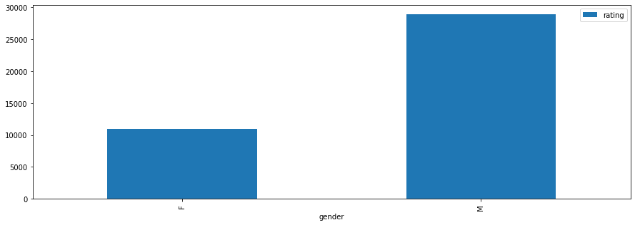

```python
#your answer here

movie_df.dropna()
movie_df.head()

drama_df = movie_df.groupby(by=['movie title','gender','Drama'])['rating'].count().reset_index().sort_values(
    ['rating'],ascending=False)

#drama_df = movie_df.groupby(by=['movie title','gender','Drama'])['rating'].count().reset_index().sort_values(
#    ['rating'],ascending=True)

drama_df.head

drama_df_1 = drama_df.where(drama_df['Drama']>0)
drama_df_1 = drama_df_1.dropna()
drama_df_1 = drama_df_1[['movie title','gender','Drama','rating']]

drama_df_1.head

drama_df_1.groupby(by=['gender'])['rating'].sum().reset_index().sort_values(
    ['rating']).plot(x='gender', kind='bar', figsize=(15,5))

plt.show()
```

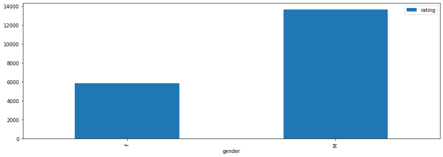

```python
#Men watch more Romance than women --> True
movie_df.dropna()
movie_df.head()

Romance_df = movie_df.groupby(by=['movie title','gender','Romance'])['rating'].count().reset_index().sort_values(['rating'],   ascending=False)

Romance_df.head
Romance_df_1 = Romance_df.where(Romance_df['Romance']>0)
Romance_df_1 = Romance_df_1.dropna()
Romance_df_1 = Romance_df_1[['movie title','gender','Romance','rating']]

Romance_df_1.head
Romance_df_1.groupby(by=['gender'])['rating'].sum().reset_index().sort_values(
    ['rating']).plot(x='gender', kind='bar',                                                                                                           figsize=(15,5))
plt.show()
```

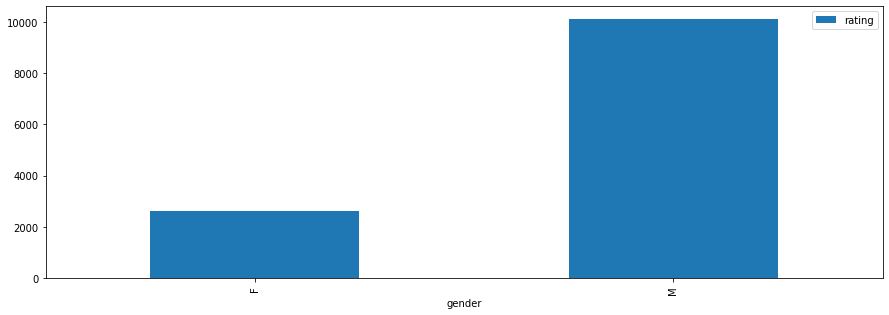

```python
#Women watch more Sci-Fi than men --> False
movie_df.dropna()
movie_df.head()

Sci_df = movie_df.groupby(by=['movie title','gender','Sci-Fi'])['rating'].count().reset_index().sort_values(['rating'],
    ascending=False)

Sci_df.head
Sci_df_1 = Sci_df.where(Sci_df['Sci-Fi']>0)
Sci_df_1 = Sci_df_1.dropna()
Sci_df_1 = Sci_df_1[['movie title','gender','Sci-Fi','rating']]
Sci_df_1.head

Sci_df_1.groupby(by=['gender'])['rating'].sum().reset_index().sort_values(
    ['rating']).plot(x='gender', kind='bar',                                                                                                           figsize=(15,5))
plt.show()
```

### 10. See gender distribution across different genres check for the validity of the below statements - 10 marks

- Men watch more drama than women
- Women watch more Sci-Fi than men
- Men watch more Romance than women
1. There is no need to conduct statistical tests around this. Just compare the percentages and comment on the validity of the above statements.
2. you might want ot use the .sum(), .div() function here.
3. Use number of ratings to validate the numbers. For example, if out of 4000 ratings received by women, 3000 are for drama, we will assume that 75% of the women watch drama.